# Assignment 3: Incarceration Data

Garrett Ruth

## Introduction

For assignment 3 I focused on the jailed population of white people compared to the jailed population of black people. This is important as comparing actual population proportion of black to white people to the population proportion found in jail can show the disparity between incarceration rates as if police action is equal the population proportion should be equal to or at least similar to the proportion found in jail.

## Summary Information

Some important features from the data set I found the max black jailed population in the west coast was 13143.92 this was interesting as in the same region the highest white jailed population was only 7036.59. Compared to the highest populations of each race in the same county (623040 for the highest black population and 2317550 for the highest white population) the proportions for each are extremely skewed with the jail population proportion being 1.87 black people to every white person while the outside proportion for the same county being .27 black people to every white person

## Charts 1

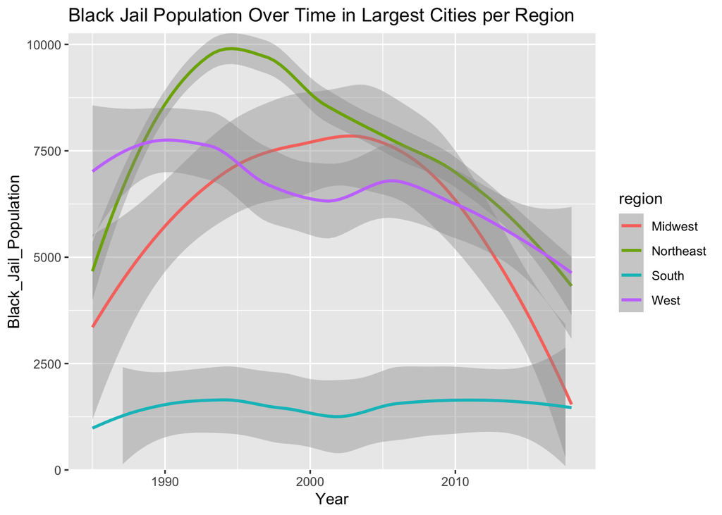

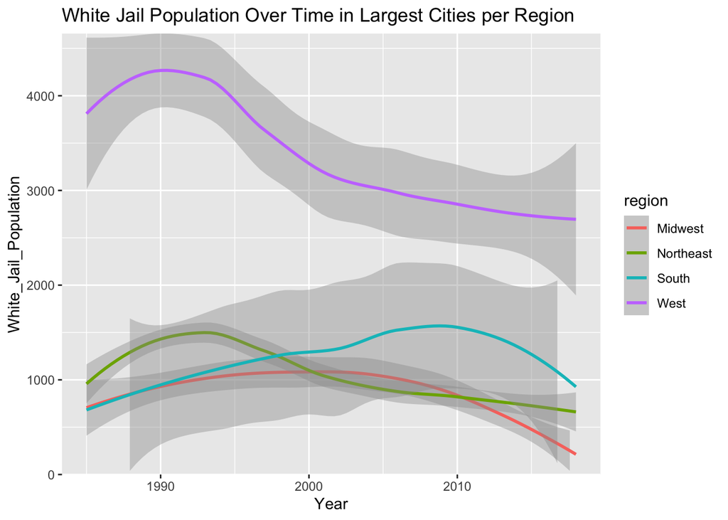

These charts were created from the county data of the most populous city in each region. From this the incredible difference between jail populations is strongly evident simply by observing the Y axis used for each graph as the black jail population graph is so much larger to account for the huge numbers of black people jailed compared to white people.

## Chart 2

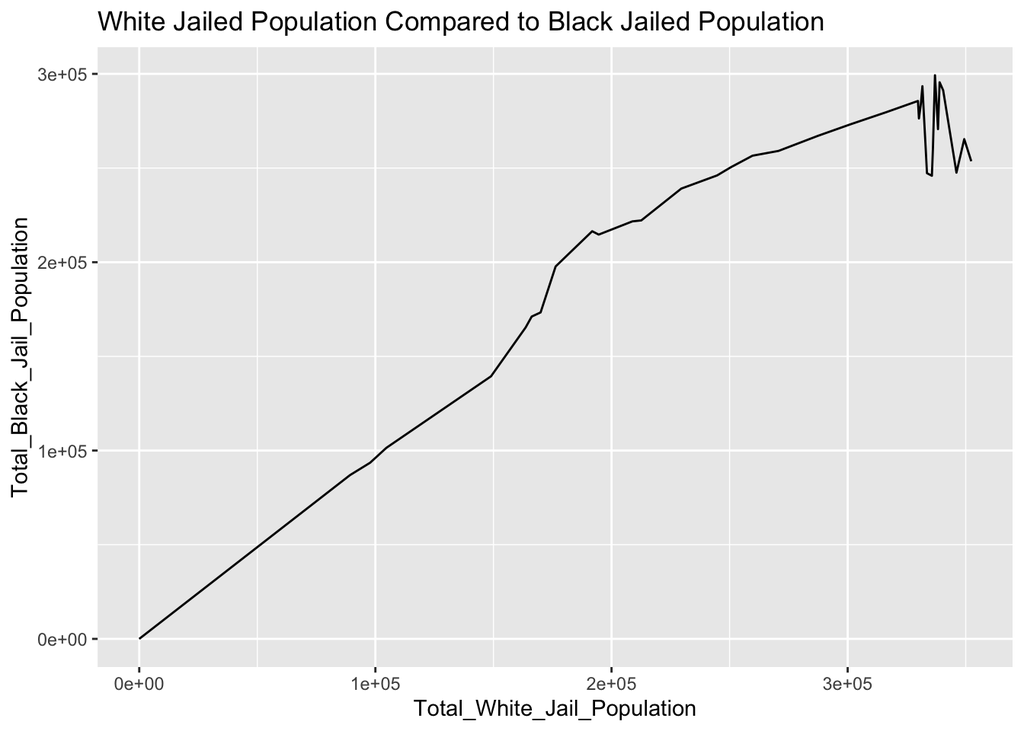

This chart shows the relationship between the total jailed white population and the total jailed black population. The graph shows another much more visible way of seeing just how close the numbers are nationwide. When viewing this graph its important to note that currently in the US white people make up 60% of the population compared to just 12% by black people. If people were arrested fairly the white jail population should be 5 times that if the black jailed population but the graph shows just how closely equal the actual jailed population is.

## Map Chart

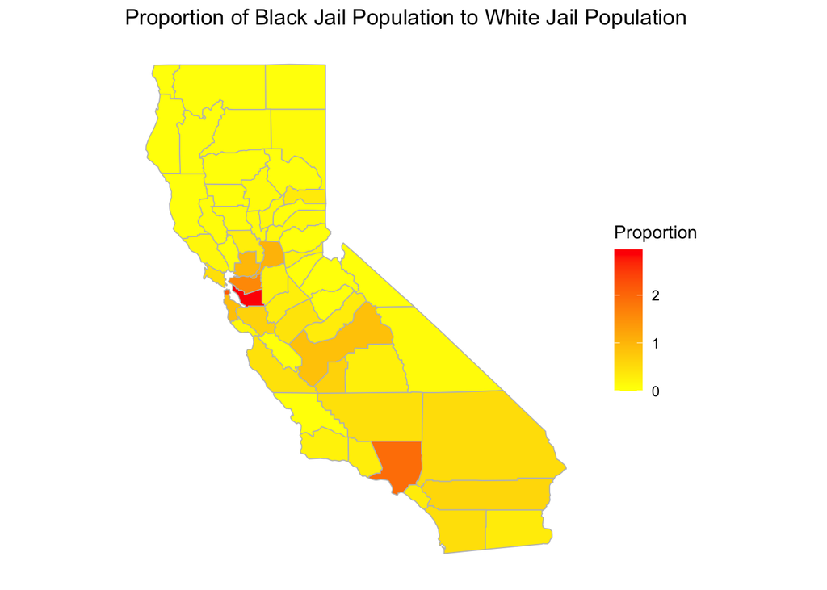

From this map we are able to see that, atleast in California, the biggest disparity in black jailed versus white jailed population proportions  
as seen in and around the major population centers in California. Surprisingly the more rural counties in California actually have much lower proportions compared to the more liberal city centers.